# R Notebook

### Name: Klysman Vieira

### Id: 230353014

# EDA Singapore Accommodations

# Introduction:

During exploratory data analysis (EDA), the dataframe that has information about accommodation in Singapore was worked on. Some dataframe columns contain the following information:

- `neighborhood_group`: Indicates the region of the neighborhood where the accommodation is located.
- `name`: Name of the accommodation.
- `host_id`: ID of the host responsible for the accommodation.
- `host_name`: Host name.
- `neighborhood`: Name of the neighborhood where the accommodation is located.
- `latitude` and `longitude`: Geographic coordinates of the accommodation.
- `number_of_reviews`: Number of reviews received by the accommodation.
- `room_type`: Type of room available in the accommodation.
- `price`: Price of the accommodation.
- `availability_365`: Number of days the accommodation is available to book over the course of a year.

During exploratory data analysis, we explore and summarize the main characteristics and patterns present in these data.

1. Descriptive analysis: We perform a statistical description of the variables, such as mean, median, standard deviation, minimum and maximum. This helps us understand the distribution of data and identify potential discrepancies or outliers.
2. Handling missing or inconsistent data: We identify and handle missing or inconsistent data, such as nulls or outliers. This may involve deleting records with missing data or filling in these values with appropriate techniques.
3. Data visualization: We use graphs and visualizations to represent data in a more understandable way. For example, we can create bar charts to show the distribution of room types or a map to visualize the location of accommodations.

# Insights

- We look for interesting patterns and insights in the data that can be useful for decision-making or answering specific questions. For example, we may discover that certain neighborhoods have a greater availability of accommodation throughout the year or that certain room types have a direct relationship with price.
- There are relationships between the variables present in the dataframe. For example, we can analyze whether the price of accommodation varies according to the region of the neighborhood or whether there is any correlation between the number of reviews and availability throughout the year.

## Loading the raw dataframe

```r
library(readxl)

file_path <- "G:/My Drive/IPS/Mestrado/UCs/Aprendizage supervisionada/IPS-ESCE SP ML/Session 3/Data/Singapore Airbnb - Raw.xlsx"

data <- read_excel(file_path)

num_rows <- dim(data)[1]
num_cols <- dim(data)[2]

column_names <- colnames(data)

cat("Number of rows:", num_rows, "\n")
```

```
Number of rows: 7923
```

```r
cat("Number of columns:", num_cols, "\n")
```

```
Number of columns: 16
```

```r
cat("Column names:", paste(column_names, collapse = ", "), "\n")
```

```
Column names: id, name, host_id, host_name, neighbourhood_group, neighbourhood, latitude, longitude, room_type, price, minimum_nights, number_of_reviews, last_review, reviews_per_month, calculated_host_listings_count, availability_365
```

## Checking for missing data

```r
missing_values <- colSums(is.na(data))

print("Number of missing values in each column:")
```

```
[1] "Number of missing values in each column:"
```

```r
print(missing_values)
```

```
                            id                           name
                             0                              5
                       host_id                      host_name
                            13                              0
           neighbourhood_group                  neighbourhood
                             0                              0
                      latitude                      longitude
                            20                              9
                     room_type                          price
                             0                              0
                minimum_nights              number_of_reviews
                             0                              4
                   last_review              reviews_per_month
                          2773                           2773
calculated_host_listings_count               availability_365
                             0                              0
```

## Display the first rows of data

```r
head(data)
```

| id | name | host_id | host_name | neighbourhood_group | neighbourhood | latitude | longitude | room_type | price | minimum_nights | number_of_reviews | last_review | reviews_per_month | calculated_host_listings_count | availability_365 |
| --- | --- | --- | --- | --- | --- | --- | --- | --- | --- | --- | --- | --- | --- | --- | --- |
| 49091 | COZICOMFORT LONG TERM STAY ROOM 2 | 266763 | Francesca | North Region | Woodlands | 1.44255 | 103.7958 | Private room | 83 | 180 | 1 | 2013-10-21 | 0.01 | 2 | 365 |
| 50646 | Pleasant Room along Bukit Timah | 227796 | Sujatha | Central Region | Bukit Timah | 1.33235 | 103.7852 | Private room | 81 | 90 | 18 | 2014-12-26 | 0.28 | 1 | 365 |
| 56334 | COZICOMFORT | 266763 | Francesca | North Region | Woodlands | 1.44246 | 103.7967 | Private room | 69 | 6 | 20 | 2015-10-01 | 0.20 | 2 | 365 |
| 71609 | Ensuite Room (Room 1 & 2) near EXPO | 367042 | Belinda | East Region | Tampines | 1.34541 | 103.9571 | Private room | 206 | 1 | 14 | 2019-08-11 | 0.15 | 9 | 353 |
| 71896 | B&B Room 1 near Airport & EXPO | 367042 | Belinda | East Region | Tampines | 1.34567 | 103.9596 | Private room | 94 | 1 | 22 | 2019-07-28 | 0.22 | 9 | 355 |
| 71903 | Room 2-near Airport & EXPO | 367042 | Belinda | East Region | Tampines | 1.34702 | 103.9610 | Private room | 104 | 1 | 39 | 2019-08-15 | 0.38 | 9 | 346 |

## Statistical data about the dataframe

```r
summary(data)
```

```
       id               name              host_id
 Min.   :   49091   Length:7923        Min.   :    23666
 1st Qu.:15824582   Class :character   1st Qu.: 23129381
 Median :24707713   Mode  :character   Median : 63448912
 Mean   :23404133                      Mean   : 91313156
 3rd Qu.:32365800                      3rd Qu.:155656938
 Max.   :38112762                      Max.   :288567551
                                       NA's   :13
  host_name         neighbourhood_group neighbourhood
 Length:7923        Length:7923         Length:7923
 Class :character   Class :character    Class :character
 Mode  :character   Mode  :character    Mode  :character




    latitude       longitude      room_type
 Min.   :1.244   Min.   :103.6   Length:7923
 1st Qu.:1.296   1st Qu.:103.8   Class :character
 Median :1.311   Median :103.8   Mode  :character
 Mean   :1.314   Mean   :103.8
 3rd Qu.:1.322   3rd Qu.:103.9
 Max.   :1.455   Max.   :104.0
 NA's   :20      NA's   :9
     price         minimum_nights    number_of_reviews
 Min.   :    0.0   Min.   :   1.00   Min.   :  0.00
 1st Qu.:   65.0   1st Qu.:   1.00   1st Qu.:  0.00
 Median :  124.0   Median :   3.00   Median :  2.00
 Mean   :  192.3   Mean   :  17.53   Mean   : 12.73
 3rd Qu.:  199.0   3rd Qu.:  10.00   3rd Qu.: 10.00
 Max.   :65000.0   Max.   :1000.00   Max.   :323.00
                                     NA's   :4
  last_review                     reviews_per_month
 Min.   :2013-10-21 00:00:00.00   Min.   : 0.010
 1st Qu.:2018-11-21 00:00:00.00   1st Qu.: 0.180
 Median :2019-06-27 00:00:00.00   Median : 0.550
 Mean   :2019-01-11 17:33:01.04   Mean   : 1.044
 3rd Qu.:2019-08-07 00:00:00.00   3rd Qu.: 1.370
 Max.   :2019-08-27 00:00:00.00   Max.   :13.000
 NA's   :2773                     NA's   :2773
 calculated_host_listings_count availability_365
 Min.   :  1.00                 Min.   :  0.0
 1st Qu.:  2.00                 1st Qu.: 54.0
 Median :  9.00                 Median :260.0
 Mean   : 40.55                 Mean   :208.7
 3rd Qu.: 48.00                 3rd Qu.:355.0
 Max.   :274.00                 Max.   :365.0
```

# Data cleaning

```r
#Remover colunas desnecessárias
data <- data[, c("neighbourhood_group", "name", "host_id", "host_name", "neighbourhood", "latitude", "number_of_reviews", "longitude", "room_type", "price", "availability_365")]
```

## Filter only complete rows (no null values)

```r
data_clean <- data[complete.cases(data), ]
```

## Identify and remove duplicate elements

```r
data_unique <- subset(data_clean, !duplicated(data_clean))
```

## Boxplot to understand the distribution of data depending on the price column

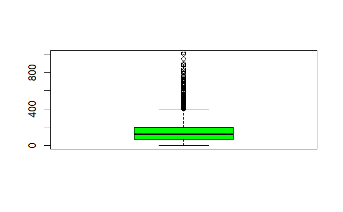

```r
# Seleciona as colunas desejadas para criar os boxplots
boxplot(data_unique$price, col = "green", ylim = c(0, 1000))
```

## Remove lines (outliers) where price >= 500

```r
data_filtered_500 <- subset(data_unique, price < 500)
```

# Graphics

## Create a boxplot for the price column

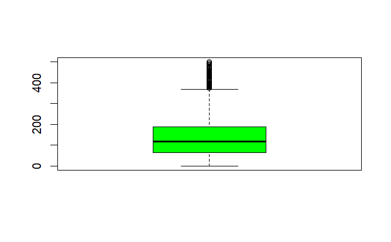

```r
boxplot_output <- boxplot(data_filtered_500$price, col = "green", ylim = c(0, 500))
```

```r
# Acessa os resultados matemáticos do boxplot
min_value <- boxplot_output$stats[1]
q1 <- boxplot_output$stats[2]
median <- boxplot_output$stats[3]
q3 <- boxplot_output$stats[4]
max_value <- boxplot_output$stats[5]

# Imprime os resultados
cat("Valor mínimo:", min_value, "\n")
```

```
Valor mínimo: 0
```

```r
cat("Primeiro quartil:", q1, "\n")
```

```
Primeiro quartil: 65
```

```r
cat("Mediana:", median, "\n")
```

```
Mediana: 119
```

```r
cat("Terceiro quartil:", q3, "\n")
```

```
Terceiro quartil: 187
```

```r
cat("Valor máximo:", max_value, "\n")
```

```
Valor máximo: 369
```

## Create a bar chart for the “room_type” column

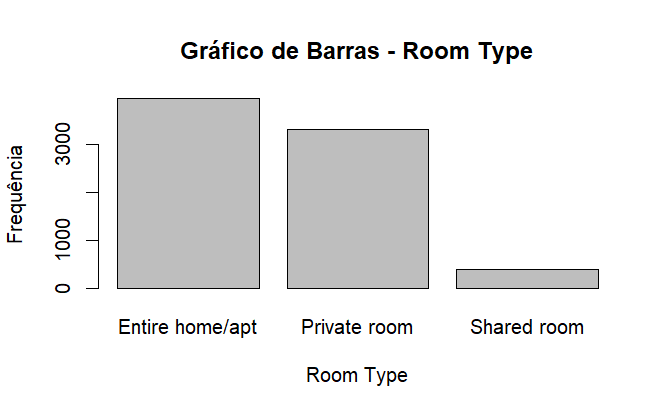

```r
barplot(table(data_filtered_500$room_type), main = "Gráfico de Barras - Room Type", xlab = "Room Type", ylab = "Frequência")
```

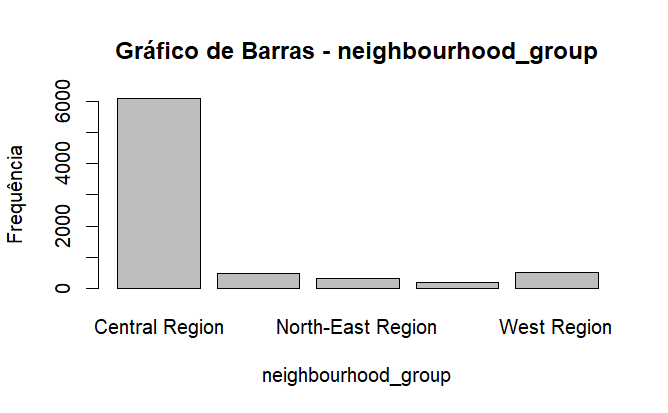

```r
barplot(table(data_filtered_500$neighbourhood_group), main = "Gráfico de Barras - neighbourhood_group", xlab = "neighbourhood_group", ylab = "Frequência")
```

```r
# Obtém o índice da linha com o maior valor em number_of_reviews
index <- which.max(data_filtered_500$number_of_reviews)

# Obtém a linha completa com o maior valor em number_of_reviews
row_with_max_reviews <- data_filtered_500[index, ]

# Imprime a linha completa
print(row_with_max_reviews)
```

| neighbourhood_group | name | host_id | host_name | neighbourhood | latitude | number_of_reviews | longitude | room_type | price | availability_365 |
| --- | --- | --- | --- | --- | --- | --- | --- | --- | --- | --- |
| East Region | Luxuriously Spacious Studio Apt. | 7642747 | Shirley | Bedok | 1.32122 | 323 | 103.9149 | Entire home/apt | 139 | 239 |

```r
NA
```

# GGPLOT2

### Bar graphs

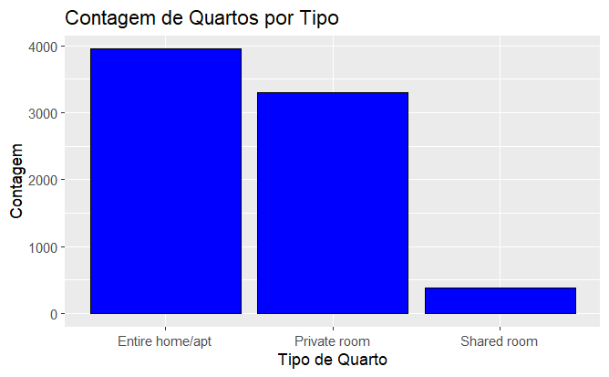

```r
library(ggplot2)

# Cria o gráfico de barras usando ggplot2
ggplot(data_filtered_500, aes(x = room_type)) +
  geom_bar(fill = "blue", color = "black") +
  labs(x = "Tipo de Quarto", y = "Contagem") +
  ggtitle("Contagem de Quartos por Tipo")
```

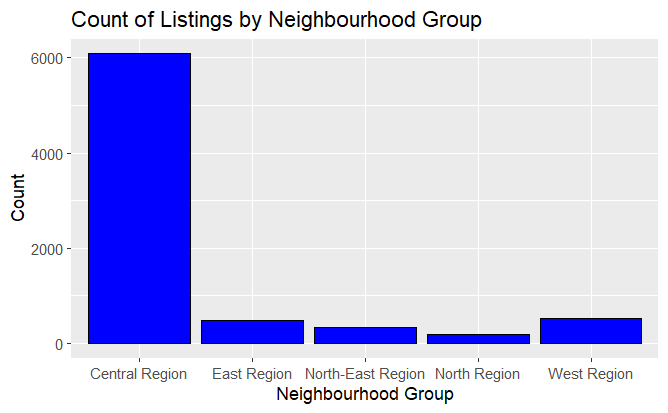

```r
ggplot(data_filtered_500, aes(x = neighbourhood_group)) +
  geom_bar(fill = "blue", color = "black") +
  labs(x = "Neighbourhood Group", y = "Count") +
  ggtitle("Count of Listings by Neighbourhood Group")
```

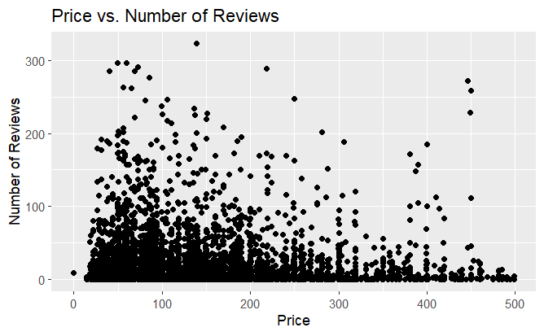

```r
ggplot(data_filtered_500, aes(x = price, y = number_of_reviews)) +
  geom_point() +
  labs(x = "Price", y = "Number of Reviews") +
  ggtitle("Price vs. Number of Reviews")
```

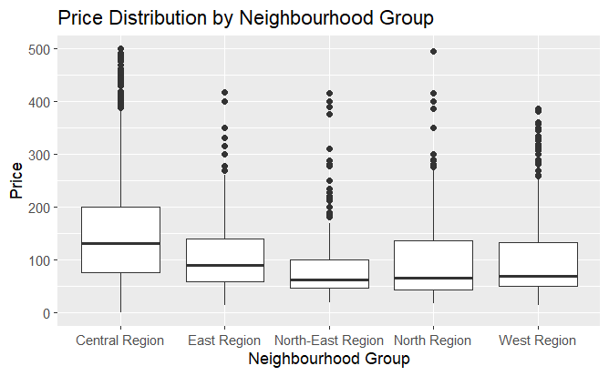

```r
ggplot(data_filtered_500, aes(x = neighbourhood_group, y = price)) +
  geom_boxplot() +
  labs(x = "Neighbourhood Group", y = "Price") +
  ggtitle("Price Distribution by Neighbourhood Group")
```

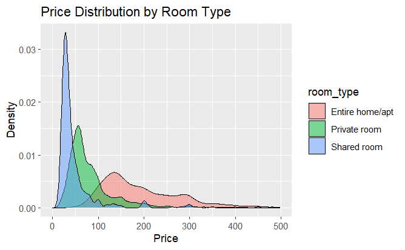

```r
ggplot(data_filtered_500, aes(x = price, fill = room_type)) +
  geom_density(alpha = 0.5) +
  labs(x = "Price", y = "Density") +
  ggtitle("Price Distribution by Room Type")
```

#salvando o novo dataframe data_filtered_500_price em formato XLSX

```r
library(openxlsx)
new_data <- "G:/My Drive/IPS/Mestrado/UCs/Aprendizage supervisionada/IPS-ESCE SP ML/Session 3/Data/data_filtered_500_price.xlsx"
write.xlsx(data_filtered_500, file = new_data)
```